# TP2 Analyse de données (avec tidyverse)

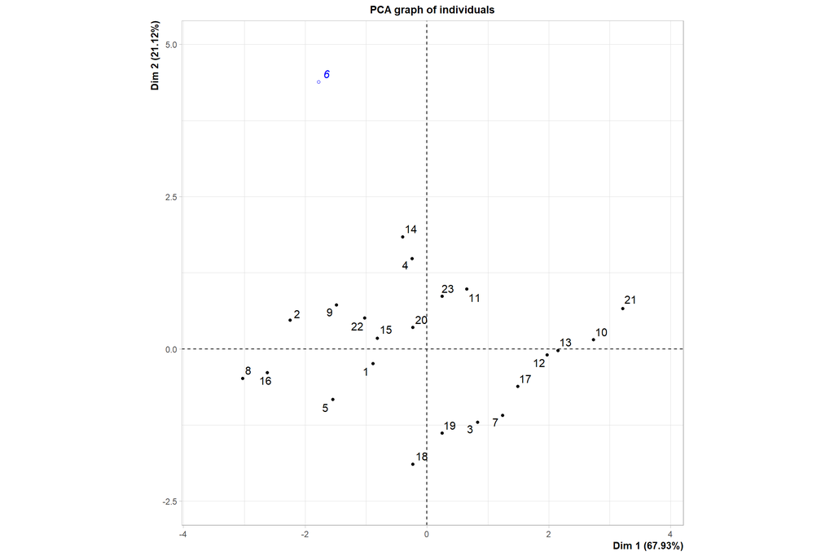

```r
plot(res_acp, axes = c(1,2), choix = 'ind')
```

Sur ce graph, nous pouvons voir une structure intéressante qui semble séparer deux groupes non homogènes, mais qui présentent tous deux un comportement similaire. Dans la partie gauche, le plus gros groupe associé aux faible valeurs de $Z_1$, $Z_2$ et $Z_3$, et à droite le plus petit associé à de plus forte valeurs de ces variables. Dans chacun des groupes par contre, il semble qu'une augmentation des variables $Z_1$, $Z_2$ et $Z_3$ est associé avec une hausse de la variable $Z_4$ en même temps (car les individus vont vers le haut à mesure que l'on va vers la droite). Si il nous manque plus d'informations sur l'interprétation physique de ces variables, il n'est pas impossible de penser que l'on pourrait en fait avoir affaire à deux populations distinctes de papillons. Passons à l'AFC à présent, qui va traiter ces variables quantitatives discrètes comme si elles résultaient du comptage dans un tableau de contingence de différentes modalités d'une même variable. Comme précédemment, nous écartons le 6ème individu.

```r
res_ca = CA(db, ncp = 3, row.sup = 6, graph = F)
```

Intéressons nous tout d'abord au nombre d'axes via la variance expliquée. On voit ci dessous que si le premier axe exprime à lui seul une grosse partie de la variance, en considérant le deuxième axe 'gratuit', nous avons carrément 99%, soit la quasi totalité, de l'information disponible. Nous n'allons donc pas nous priver ici de considérer les deux premiers axes factoriels.

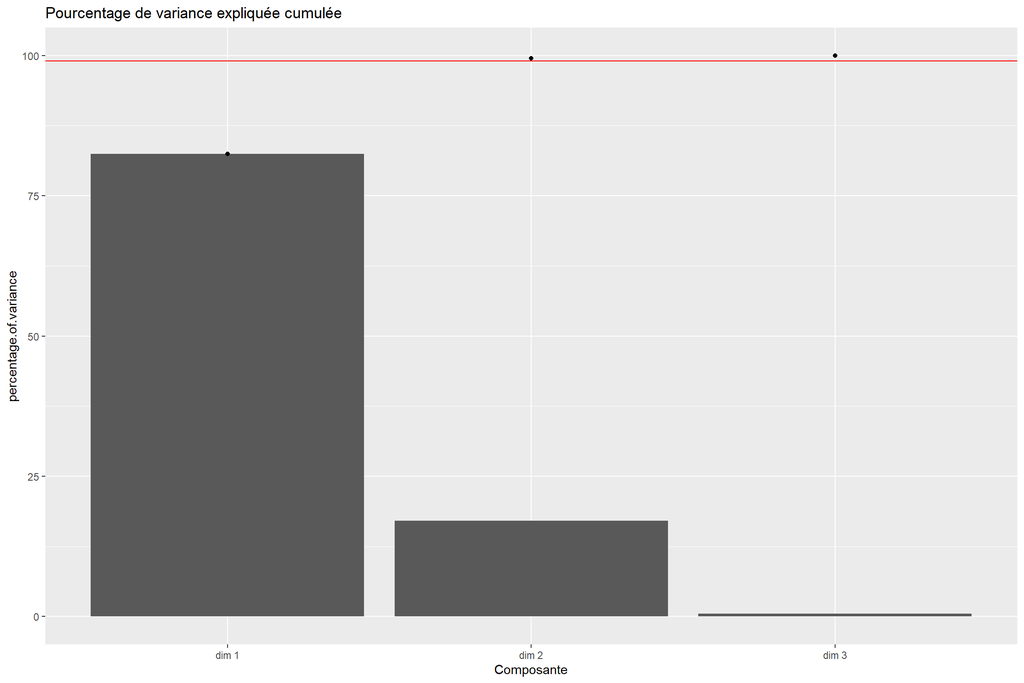

```r
vp = res_ca$eig %>% data.frame %>% rownames_to_column(var = 'Composante') %>% as_tibble
ggplot(vp) + geom_col(aes(x = Composante, y = percentage.of.variance)) +
             geom_point(aes(x = Composante, y = cumulative.percentage.of.variance)) +
             ggtitle("Pourcentage de variance expliquée cumulée") +
             geom_hline(aes(yintercept = 99), color = 'red')
```

Faisons une rapide vérification des contributions et représentations à l'aide d'un summary des premiers profils lignes et des profils colonnes.

```r
summary(res_ca)
```

```
##
## Call:
## CA(X = db, ncp = 3, row.sup = 6, graph = F)
##
## The chi square of independence between the two variables is equal to 16.2562 (p-value =  1 ).
##
## Eigenvalues
##                        Dim.1   Dim.2   Dim.3
## Variance               0.006   0.001   0.000
## % of var.             82.446  17.042   0.512
## Cumulative % of var.  82.446  99.488 100.000
##
## Rows (the 10 first)
##      Iner*1000    Dim.1    ctr   cos2    Dim.2    ctr   cos2    Dim.3    ctr
## 1  |     0.147 |  0.025  0.453  0.180 | -0.053  9.995  0.820 |  0.001  0.115
## 2  |     0.611 |  0.115  9.681  0.922 |  0.031  3.365  0.066 |  0.013 20.283
## 3  |     0.380 | -0.090  6.266  0.959 |  0.018  1.213  0.038 |  0.004  2.230
## 4  |     0.297 |  0.076  4.682  0.917 |  0.022  1.999  0.081 |  0.003  1.361
## 5  |     0.131 |  0.023  0.368  0.163 | -0.051  8.968  0.821 |  0.007  6.045
## 7  |     0.440 | -0.098  7.521  0.994 |  0.004  0.052  0.001 |  0.007  5.809
## 8  |     0.459 |  0.105  7.442  0.943 |  0.023  1.695  0.044 | -0.012 16.132
## 9  |     0.411 |  0.093  6.533  0.924 |  0.026  2.492  0.073 |  0.005  3.184
## 10 |     0.392 | -0.087  6.617  0.984 |  0.011  0.503  0.015 | -0.003  1.081
## 11 |     0.213 |  0.022  0.407  0.111 | -0.063 15.731  0.886 |  0.003  1.557
##      cos2
## 1   0.000 |
## 2   0.012 |
## 3   0.002 |
## 4   0.002 |
## 5   0.017 |
## 7   0.005 |
## 8   0.013 |
## 9   0.003 |
## 10  0.001 |
## 11  0.003 |
##
## Columns
##      Iner*1000    Dim.1    ctr   cos2    Dim.2    ctr   cos2    Dim.3    ctr
## Z1 |     1.136 | -0.035  5.065  0.259 |  0.059 69.930  0.740 |  0.001  0.559
## Z2 |     0.453 | -0.029  5.030  0.646 | -0.020 11.847  0.315 | -0.007 48.820
## Z3 |     0.731 | -0.046  8.486  0.676 | -0.031 18.202  0.300 |  0.009 50.082
## Z4 |     4.739 |  0.162 81.419  1.000 | -0.001  0.022  0.000 |  0.001  0.539
##      cos2
## Z1  0.000 |
## Z2  0.039 |
## Z3  0.025 |
## Z4  0.000 |
##
## Supplementary row
##      Dim.1  cos2   Dim.2  cos2   Dim.3  cos2
## 6  | 0.249 0.993 | 0.017 0.004 | 0.013 0.003 |
```

Nous voyons que les profils lignes sont soit bien représenté sur le premier axe, ou sur le deuxième mais jamais les deux la fois. Il semble qu'une claire distinction soit faite entre les composantes à ce niveau. En ce qui concerne les profils colonnes, le premier axe concentre toute l'information de $Z_4$ et dans une moindre mesure de $Z_2$ et $Z_3$. Le deuxième axe quan à lui est majoritairement dirigé par $Z_1$ avec une légère contribution de $Z_2$ et $Z_3$. Voyons ce qu'il en résulte dans l'analyse graphique à présent.

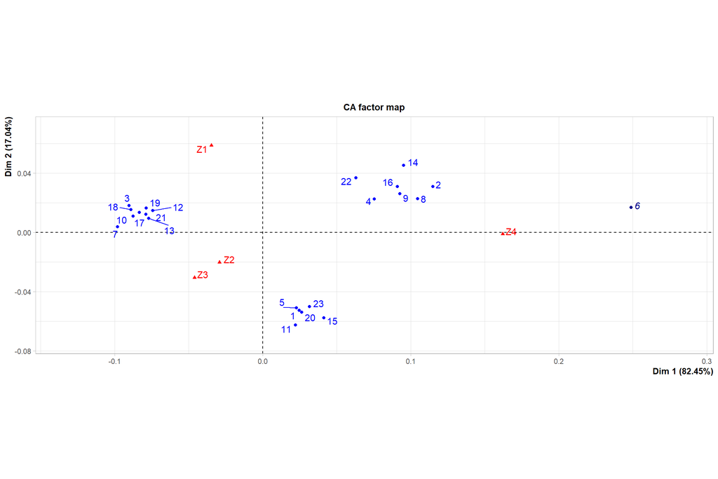

```r
plot(res_ca, axes = c(1,2))
```

Sur la question de la comparaison entre l'ACP et l'AFC sur cet exemple précis, nous serions tenter de considérer l'AFC comme plus appropriée ici. En effet, de part les résultats qui semblent plus clairs, et du fait que seulement deux axes ont suffit à donner une analyse très fine des données. Cependant, l'information globale qui ressort est en fait très similaire (ce qui est rassurant pour un même jeu de données), notamment lorsque l'on prend le temps d'analyser le troisième axe de l'ACP (comme proposé ci dessous). Rappellons nous que **l'AFC n'est qu'un cas particulier d'ACP**, qui est justement bien adapté pour analyser des tableaux de contigence, qui par définition contiennent des valeurs numériques discrètes. L'ACP est quelque part plus generale, et il n'est pas vraiment étonnant de voir que l'AFC fonctionne légèrement 'mieux' dans son cadre d'application idéale. Cependant, dans le cas de variables numériques continues, nous n'aurions de toute façon d'auter choix que d'effectuer une ACP. Pour finir, notez bien que cet exemple est majoritairement illustratif. Dans un cadre général, ces deux méthodes ne sont **pas vraiment en concurence** dans le sens où elles n'ont **pas le même cadre d'application** (*variables quantitatives* vs *modalités de variables qualitatives*, comme détaillé dans les exercices précédents).

### Bonus: la 3ème composante principal de l'ACP

Comme souvent précisé en TP, la sélection du nombre d'axes en ACP ou AFC est avant tout une question de **priorités et de temps** que l'on souhaite consacrer à l'analyse. Pour atteindre 99% de variance expliquée, nous aurions pu selectionner un troisième axe dans notre ACP, suceptible de nous renseigner sur des caractéristiques plus *subtiles* du jeu de données, peut être ignorées jusque là. Nous voyons en effet dans le cercle des corrélations une nouvelle distinction qui est mise en avant. Si la variable Z_4 est quasiment ignorée, nous avons maintenant une nette opposition qui se dégage entre $Z_1$ et le couple $Z_2$-$Z_3$ selon la troisème composante principale, alors que la première les rassemblent toutes.

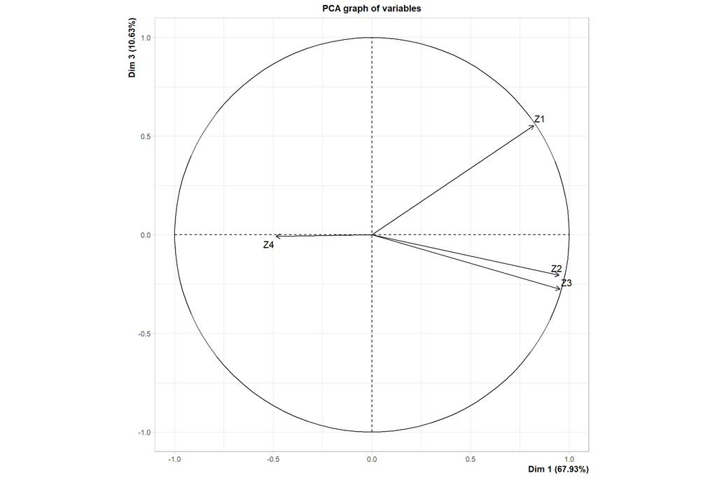

```r
plot(res_acp, axes = c(1,3), choix = 'var')
```

Voyons sur ce plan factoriel *composante1-composante3* si cette distinction dévoile de nouvelles structures de groupes parmi nos individus.

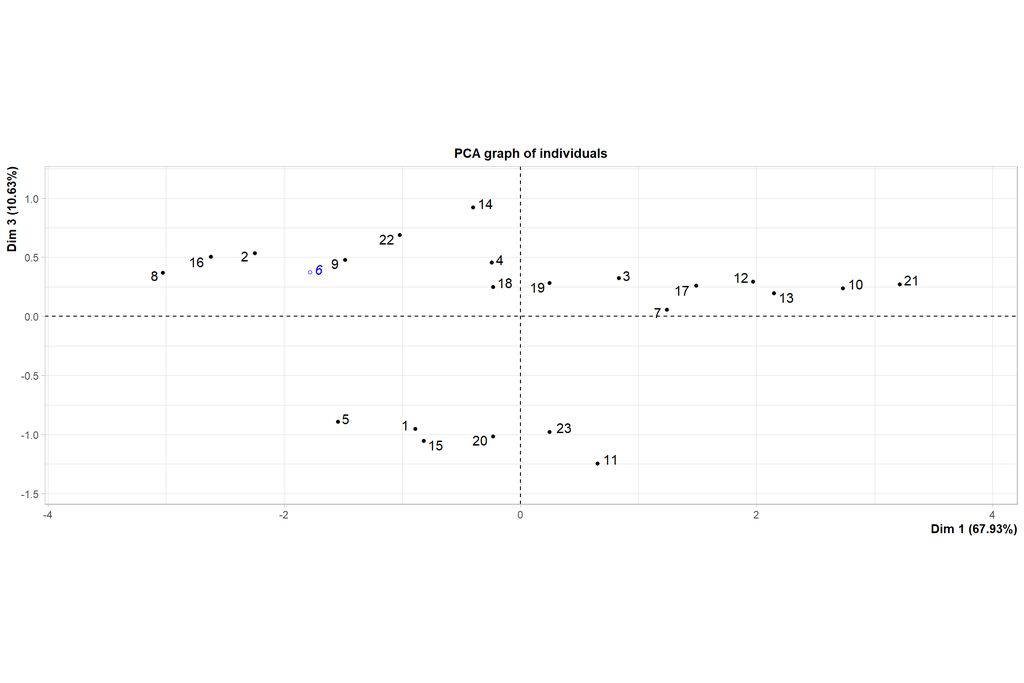

```r
plot(res_acp, axes = c(1,3), choix = 'ind')
```

On voit en effet une nette opposition qui se créer en isolant un groupe de 6 individus en bas qui présentent de faible valeur de $Z_1$ (dans une moindre mesure associée à de hautes valeurs de $Z_2$ et $Z_3$). Le groupe du haut pour sa part présente des caractéristiques inverses. Sachant que l'on a déjà analysé la première composante principale, nous arrêtons l'analyse à ce nouvel aspect, qui révèle une information certes moins évidente, mais que l'on avait passé sous silence dans la première analyse 'rapide'.  
Bien que les variables ne sont pas ici explicitées, nous pourrions imaginer dans un cas analogue pour les êtres humains, des variables $Z_1$, $Z_2$ et $Z_3$ étant respectivement le *poids*, la *taille* et la *taille des jambes*. Si dans une analyse grossière, on pourrait imaginer que ces 3 variables soient très corrélées du fait que plus l'on est grand, plus généralement on pèse lourd, les deux dernières variables sont en fait bien plus corrélées entre elles qu'avec le poids, qui peut fluctuer. Dans un tel cas, nous aurions aussi probablement une distinction qui se ferait entre la variable poids et les variables de taille en regardant des 'petits' axes de l'ACP, associées à de plus faibles valeurs propres. Cet exemple est bien sûr fictif mais tente d'illustrer le phénomène observé ci-dessus avec des variables ne représentant rien de très concret dans le cas des papillons.